# Presentazione Dataset e analisi per progetti di Gruppo

Rodolfo Metulini

2023-11-30

### Come scrivere il report (consigli generali validi anche per il futuro):

1. Descrizione del problema e dei dati: descrivere qual è lo scopo dell’analisi e descrivere quante e quali variabili si hanno.
2. EDA (Exploration Data Analysis): boxplot, correlation plot, barplot, tables.
3. Data Engineering (optional): create or add new variables.
4. Missing imputation (non richiesto per questo progetto) e outlier detection: spesso gli outlier vengono rimossi o tenuti da conto per l’analisi di un dataset.
5. Feature selection: decidere quali variabili entrano in gioco nell’analisi e perché, giustificare le proprie scelte o utilizzare modelli che aiutino a fare queste scelte.
6. Model selection: fare fitting di diversi modelli e confrontarli per scegliere il modello migliore per i vostri dati.
7. Conclusioni: concludere esplicitando a cosa è servito il modello finale e se avete risposto alla domanda di ricerca presentata al primo punto.
8. Bibliografia: è buona norma includere le fonti utilizzate per produrre il vostro report (paper di riferimento, ecc.).

### BASKETBALL TEAMS’ DATASET

```r
setwd("C:\\Users\\bnsda\\Desktop\\Progetti_R\\PROGETTO\\MATERIALE")
ds = read.delim("basketball_teams.txt")
head (ds)
```

```
##   year lgID tmID franchID confID divID rank confRank playoff
## 1 1946  NBA  BOS      BOS           ED    5        0
## 2 1946  NBA  CHS      CHS           WD    1        0       F
## 3 1946  NBA  CLR      CLR           WD    3        0      R1
## 4 1946  NBA  DTF      DTF           WD    4        0
## 5 1946  NBA  NYK      NYK           ED    3        0      SF
## 6 1946  NBA  PHW      GSW           ED    2        0      NC
##                    name o_fgm o_fga o_ftm o_fta o_3pm o_3pa o_oreb o_dreb o_reb
## 1        Boston Celtics  1397  5133   811  1375     0     0      0      0     0
## 2         Chicago Stags  1879  6309   939  1550     0     0      0      0     0
## 3      Cleveland Rebels  1674  5699   903  1428     0     0      0      0     0
## 4       Detroit Falcons  1437  5843   923  1494     0     0      0      0     0
## 5       New York Knicks  1465  5255   951  1438     0     0      0      0     0
## 6 Philadelphia Warriors  1510  5384  1098  1596     0     0      0      0     0
##   o_asts o_pf o_stl o_to o_blk o_pts d_fgm d_fga d_ftm d_fta d_3pm d_3pa d_oreb
```

[output cut: 34 more lines]

# Analisi delle variabili del dataset

year: stagione del torneo

lgID: nome della lega

franchID: nome squadra 3 cifre

confID: Conference di appartenenza della squadra

divID: Division di appartenenza della squadra

rank: classifica fine stagione regolare nella division

confRank: classifica fine stagione regolare nella conference

playoff: qualifica ai playoff (come da legenda)

name: nome squadra

o_: offensive

d_: defensive

fgm: tiri realizzati su azione

fga: tiri tentati su azione

ftm: tiri liberi realizzati

fta: tiri liberi tentati

3pm: tiri da 3 realizzati

3pa: tiri da 3 tentati

oreb: rimbalzi offensivi

dreb: rimbalzi difensivi

reb: rimbalzi totali (offensivi + difensivi)

asts: assists

pf: falli commessi

stl: palle recuperate

to: palle perse

blk: palle stoppate

tmRebound: rimbalzi di squadra

homeWon: vittore in casa

homeLost: sconfitte in casa

awayWon: vittorie in trasferta

awayLost: sconfitte in trasferta

neutWon: vittorie in campo neutro

neutLoss: sconfitte in campo neutro

confWon: vittorie contro squadre della stessa conference

confLoss: sconfitte contro squadre della stessa conference

divWon: vittorie con squadre stessa division

divLoss: sconfitte con squadre stessa division

won: vittorie totali

lost: sconfitte totali

games: partite giocate totali in stagione (won + lost)

min: minuti giocati in stagione

arena: nome stadio

attendance: numero spettatori

# progetto 1:

ABA league (1967-1975): VARIABILE DIPENDENTE: qualificazione ai playoff (SI/NO) e/o la vittoria di almeno la metà delle partite

COVARIATE: tutte le altre (o uno specifico insieme di queste, in base all’obiettivo di analisi)

attenzione che rimbalzi offensivi e difensivi, recuperi e stoppate, sono state rilevate solo a partire da un certo anno

# progetto 2:

NBA moderna (1976-2011): VARIABILE DIPENDENTE: qualificazione ai playoff (SI/NO)

COVARIATE: tutte le altre (o uno specifico insieme di queste, in base all’obiettivo di analisi)

# progetto 3:

NBA moderna (1976-2011): VARIABILE DIPENDENTE: qualificazione alle finali (SI/NO)

COVARIATE: tutte le altre (o uno specifico insieme di queste, in base all’obiettivo di analisi)

# progetto 4:

NBA moderna (1976-2011): VARIABILE DIPENDENTE: vittoria del titolo (SI/NO)

COVARIATE: tutte le altre (o uno specifico insieme di queste, in base all’obiettivo di analisi)

# progetto 5:

NBA moderna (1976-2011): VARIABILE DIPENDENTE: numero di vittorie in stagione

COVARIATE: tutte le altre (o uno specifico insieme di queste, in base all’obiettivo di analisi)

attenzione: qui considerare solo le squadre che hanno giocato 82 partite (dataset$games==82)

# progetto 6:

Confronto NBA moderna (1976-2011) e ABA (1967-1975): VARIABILE DIPENDENTE: qualificazione ai playoff (SI/NO)

COVARIATE: tutte le altre.

QUESITO: Le variabili che determinano la qualificazione ai playoff sono diverse nelle 2 leghe?

# Possibili quesiti di ricerca

1. Quanto è importante avere una buona precisione nel realizzare (da 2, da 3, ai liberi)?
2. Quanto è importante che gli avversari tirino male?
3. Qual’è l’effetto di prendere più rimbalzi degli avversari e di recuperare molti palloni (stl, blk)
4. è importante saper vincere anche fuori casa per qualificarsi ai playoff?
5. è importante vincere contro le squadre delle propria division per vincere il titolo?
6. l’effetto delle variabili esplicative è cambiato nel corso del tempo? (dummy temporale)
7. ci sono arene per cui giocare li aiuta a vincere o a qualificarsi ai playoff?

# Operazioni utili

```r
# select league
nba = ds[ds$lgID=="NBA",]
aba = ds[ds$lgID=="ABA",]
nbl = ds[ds$lgID=="NBL",]

# define the variable: "qualified for the playoff"
ds$DP_playoff = 0
ds$DP_playoff[ds$playoff !=""] = 1

# define the variable: "went to the finals"
ds$DP_playoff = 0
ds$DP_playoff[ds$playoff =="F"] = 1

# define the variable: "won the title"
ds$DP_playoff = 0
ds$DP_playoff[ds$playoff =="Won NBA championship"] = 1

# choose selected years
first = 2000 # first year
last = 2009 # last year
dsy = ds[ds$year >= first & ds$year <= last,]
```

# Analisi preliminari

```r
# Vediamo se ci sono valori mancanti nel dataset:
sum(is.na(ds))
```

```
## [1] 214
```

```r
# usiamo il summary pervedere in quali variabili
summary(ds)
```

```
##       year          lgID               tmID             franchID
##  Min.   :1937   Length:1536        Length:1536        Length:1536
##  1st Qu.:1968   Class :character   Class :character   Class :character
##  Median :1984   Mode  :character   Mode  :character   Mode  :character
##  Mean   :1981
##  3rd Qu.:1999
##  Max.   :2011
##
##     confID             divID                rank          confRank
##  Length:1536        Length:1536        Min.   :0.000   Min.   : 0.000
##  Class :character   Class :character   1st Qu.:2.000   1st Qu.: 0.000
##  Mode  :character   Mode  :character   Median :3.000   Median : 3.000
##                                        Mean   :3.346   Mean   : 4.397
##                                        3rd Qu.:5.000   3rd Qu.: 8.000
##                                        Max.   :9.000   Max.   :15.000
##
##    playoff              name               o_fgm          o_fga
##  Length:1536        Length:1536        Min.   :   0   Min.   :   0
##  Class :character   Class :character   1st Qu.:2840   1st Qu.:6410
##  Mode  :character   Mode  :character   Median :3170   Median :6894
##                                        Mean   :2921   Mean   :6364
##                                        3rd Qu.:3504   3rd Qu.:7471
##                                        Max.   :4059   Max.   :9295
##
##      o_ftm          o_fta          o_3pm           o_3pa
##  Min.   :   0   Min.   :   0   Min.   :  0.0   Min.   :   0.0
##  1st Qu.:1455   1st Qu.:1955   1st Qu.:  0.0   1st Qu.:   0.0
##  Median :1639   Median :2192   Median :106.0   Median : 352.5
##  Mean   :1573   Mean   :2093   Mean   :194.3   Mean   : 563.2
##  3rd Qu.:1862   3rd Qu.:2472   3rd Qu.:363.0   3rd Qu.:1060.0
##  Max.   :2607   Max.   :3434   Max.   :841.0   Max.   :2283.0
##
##      o_oreb           o_dreb         o_reb          o_asts          o_pf
##  Min.   :   0.0   Min.   :   0   Min.   :   0   Min.   :   0   Min.   :   0
##  1st Qu.:   0.0   1st Qu.:   0   1st Qu.:3318   1st Qu.:1579   1st Qu.:1704
##  Median : 962.0   Median :2356   Median :3526   Median :1818   Median :1876
##  Mean   : 741.8   Mean   :1678   Mean   :3300   Mean   :1659   Mean   :1726
##  3rd Qu.:1138.2   3rd Qu.:2499   3rd Qu.:3817   3rd Qu.:2021   3rd Qu.:2038
##  Max.   :1845.0   Max.   :3083   Max.   :6131   Max.   :2575   Max.   :2470
##
```

[output cut: 65 more lines]

```
##  Min.   : 0.00   Min.   : 2640   Length:1536        Min.   :    0
##  1st Qu.:75.00   1st Qu.:19730   Class :character   1st Qu.:32767
##  Median :82.00   Median :19780   Mode  :character   Median :32767
##  Mean   :70.62   Mean   :19149                      Mean   :25711
##  3rd Qu.:82.00   3rd Qu.:19855                      3rd Qu.:32767
##  Max.   :84.00   Max.   :20460                      Max.   :32767
##                  NA's   :214
##     bbtmID            DP_playoff
##  Length:1536        Min.   :0
##  Class :character   1st Qu.:0
##  Mode  :character   Median :0
##                     Mean   :0
##                     3rd Qu.:0
##                     Max.   :0
##
```

```r
# risulta minuti giocati
ds2 = ds[!is.na(ds$min),]
# usare quest'ultimo nel caso in cui la variabile "min" venga usata come esplicativa


# Dato che alcune variabili (lgID, franchisIDM CONFid) vengono considerate come character e non factor le trasformiamo:
str(ds)
```

```
## 'data.frame':    1536 obs. of  61 variables:
##  $ year       : int  1946 1946 1946 1946 1946 1946 1946 1946 1946 1946 ...
##  $ lgID       : chr  "NBA" "NBA" "NBA" "NBA" ...
##  $ tmID       : chr  "BOS" "CHS" "CLR" "DTF" ...
##  $ franchID   : chr  "BOS" "CHS" "CLR" "DTF" ...
##  $ confID     : chr  "" "" "" "" ...
##  $ divID      : chr  "ED" "WD" "WD" "WD" ...
##  $ rank       : int  5 1 3 4 3 2 5 4 2 5 ...
##  $ confRank   : int  0 0 0 0 0 0 0 0 0 0 ...
##  $ playoff    : chr  "" "F" "R1" "" ...
##  $ name       : chr  "Boston Celtics" "Chicago Stags" "Cleveland Rebels" "Detroit Falcons" ...
##  $ o_fgm      : int  1397 1879 1674 1437 1465 1510 1345 1629 1601 1515 ...
##  $ o_fga      : int  5133 6309 5699 5843 5255 5384 4961 5582 5877 5672 ...
##  $ o_ftm      : int  811 939 903 923 951 1098 984 1092 862 966 ...
##  $ o_fta      : int  1375 1550 1428 1494 1438 1596 1507 1666 1400 1552 ...
```

[output cut: 47 more lines]

```r
ds$lgID <- as.factor(ds$lgID)
ds$franchID <- as.factor(ds$franchID)

summary(ds)
```

```
##       year        lgID          tmID              franchID
##  Min.   :1937   ABA :  94   Length:1536        DET    :  71
##  1st Qu.:1968   ABL1:  14   Class :character   SAC    :  67
##  Median :1984   NBA :1304   Mode  :character   ATL    :  66
##  Mean   :1981   NBL :  99                      BOS    :  66
##  3rd Qu.:1999   NPBL:   9                      GSW    :  66
##  Max.   :2011   PBLA:  16                      LAL    :  66
##                                                (Other):1134
##     confID             divID                rank          confRank
##  Length:1536        Length:1536        Min.   :0.000   Min.   : 0.000
##  Class :character   Class :character   1st Qu.:2.000   1st Qu.: 0.000
##  Mode  :character   Mode  :character   Median :3.000   Median : 3.000
##                                        Mean   :3.346   Mean   : 4.397
##                                        3rd Qu.:5.000   3rd Qu.: 8.000
##                                        Max.   :9.000   Max.   :15.000
##
##    playoff              name               o_fgm          o_fga
##  Length:1536        Length:1536        Min.   :   0   Min.   :   0
##  Class :character   Class :character   1st Qu.:2840   1st Qu.:6410
##  Mode  :character   Mode  :character   Median :3170   Median :6894
##                                        Mean   :2921   Mean   :6364
##                                        3rd Qu.:3504   3rd Qu.:7471
##                                        Max.   :4059   Max.   :9295
##
##      o_ftm          o_fta          o_3pm           o_3pa
##  Min.   :   0   Min.   :   0   Min.   :  0.0   Min.   :   0.0
##  1st Qu.:1455   1st Qu.:1955   1st Qu.:  0.0   1st Qu.:   0.0
##  Median :1639   Median :2192   Median :106.0   Median : 352.5
##  Mean   :1573   Mean   :2093   Mean   :194.3   Mean   : 563.2
##  3rd Qu.:1862   3rd Qu.:2472   3rd Qu.:363.0   3rd Qu.:1060.0
##  Max.   :2607   Max.   :3434   Max.   :841.0   Max.   :2283.0
##
##      o_oreb           o_dreb         o_reb          o_asts          o_pf
##  Min.   :   0.0   Min.   :   0   Min.   :   0   Min.   :   0   Min.   :   0
##  1st Qu.:   0.0   1st Qu.:   0   1st Qu.:3318   1st Qu.:1579   1st Qu.:1704
##  Median : 962.0   Median :2356   Median :3526   Median :1818   Median :1876
##  Mean   : 741.8   Mean   :1678   Mean   :3300   Mean   :1659   Mean   :1726
##  3rd Qu.:1138.2   3rd Qu.:2499   3rd Qu.:3817   3rd Qu.:2021   3rd Qu.:2038
##  Max.   :1845.0   Max.   :3083   Max.   :6131   Max.   :2575   Max.   :2470
##
```

[output cut: 65 more lines]

```
##  Min.   : 0.00   Min.   : 2640   Length:1536        Min.   :    0
##  1st Qu.:75.00   1st Qu.:19730   Class :character   1st Qu.:32767
##  Median :82.00   Median :19780   Mode  :character   Median :32767
##  Mean   :70.62   Mean   :19149                      Mean   :25711
##  3rd Qu.:82.00   3rd Qu.:19855                      3rd Qu.:32767
##  Max.   :84.00   Max.   :20460                      Max.   :32767
##                  NA's   :214
##     bbtmID            DP_playoff
##  Length:1536        Min.   :0
##  Class :character   1st Qu.:0
##  Mode  :character   Median :0
##                     Mean   :0
##                     3rd Qu.:0
##                     Max.   :0
##
```

```r
# questo ci permette di avere una migliore rappresentazione col summary
# e anche di poter generare variabili dummy

# sintesi dati fattori
table(ds$lgID)
```

```
##
##  ABA ABL1  NBA  NBL NPBL PBLA
##   94   14 1304   99    9   16
```

```r
table(ds$year, ds$lgID)
```

```
##
##        ABA ABL1 NBA NBL NPBL PBLA
##   1937   0    0   0  13    0    0
##   1938   0    0   0   8    0    0
##   1939   0    0   0   8    0    0
##   1940   0    0   0   7    0    0
##   1941   0    0   0   7    0    0
##   1942   0    0   0   5    0    0
##   1943   0    0   0   4    0    0
##   1944   0    0   0   6    0    0
##   1945   0    0   0   8    0    0
##   1946   0    0  11  12    0    0
##   1947   0    0   8  11    0   16
##   1948   0    0  12  10    0    0
##   1949   0    0  17   0    0    0
```

[output cut: 62 more lines]

```r
# Vediamo un pochino meglio il dataset ora:
summary(ds)
```

```
##       year        lgID          tmID              franchID
##  Min.   :1937   ABA :  94   Length:1536        DET    :  71
##  1st Qu.:1968   ABL1:  14   Class :character   SAC    :  67
##  Median :1984   NBA :1304   Mode  :character   ATL    :  66
##  Mean   :1981   NBL :  99                      BOS    :  66
##  3rd Qu.:1999   NPBL:   9                      GSW    :  66
##  Max.   :2011   PBLA:  16                      LAL    :  66
##                                                (Other):1134
##     confID             divID                rank          confRank
##  Length:1536        Length:1536        Min.   :0.000   Min.   : 0.000
##  Class :character   Class :character   1st Qu.:2.000   1st Qu.: 0.000
##  Mode  :character   Mode  :character   Median :3.000   Median : 3.000
##                                        Mean   :3.346   Mean   : 4.397
##                                        3rd Qu.:5.000   3rd Qu.: 8.000
##                                        Max.   :9.000   Max.   :15.000
##
##    playoff              name               o_fgm          o_fga
##  Length:1536        Length:1536        Min.   :   0   Min.   :   0
##  Class :character   Class :character   1st Qu.:2840   1st Qu.:6410
##  Mode  :character   Mode  :character   Median :3170   Median :6894
##                                        Mean   :2921   Mean   :6364
##                                        3rd Qu.:3504   3rd Qu.:7471
##                                        Max.   :4059   Max.   :9295
##
##      o_ftm          o_fta          o_3pm           o_3pa
##  Min.   :   0   Min.   :   0   Min.   :  0.0   Min.   :   0.0
##  1st Qu.:1455   1st Qu.:1955   1st Qu.:  0.0   1st Qu.:   0.0
##  Median :1639   Median :2192   Median :106.0   Median : 352.5
##  Mean   :1573   Mean   :2093   Mean   :194.3   Mean   : 563.2
##  3rd Qu.:1862   3rd Qu.:2472   3rd Qu.:363.0   3rd Qu.:1060.0
##  Max.   :2607   Max.   :3434   Max.   :841.0   Max.   :2283.0
##
##      o_oreb           o_dreb         o_reb          o_asts          o_pf
##  Min.   :   0.0   Min.   :   0   Min.   :   0   Min.   :   0   Min.   :   0
##  1st Qu.:   0.0   1st Qu.:   0   1st Qu.:3318   1st Qu.:1579   1st Qu.:1704
##  Median : 962.0   Median :2356   Median :3526   Median :1818   Median :1876
##  Mean   : 741.8   Mean   :1678   Mean   :3300   Mean   :1659   Mean   :1726
##  3rd Qu.:1138.2   3rd Qu.:2499   3rd Qu.:3817   3rd Qu.:2021   3rd Qu.:2038
##  Max.   :1845.0   Max.   :3083   Max.   :6131   Max.   :2575   Max.   :2470
##
```

[output cut: 65 more lines]

```
##  Min.   : 0.00   Min.   : 2640   Length:1536        Min.   :    0
##  1st Qu.:75.00   1st Qu.:19730   Class :character   1st Qu.:32767
##  Median :82.00   Median :19780   Mode  :character   Median :32767
##  Mean   :70.62   Mean   :19149                      Mean   :25711
##  3rd Qu.:82.00   3rd Qu.:19855                      3rd Qu.:32767
##  Max.   :84.00   Max.   :20460                      Max.   :32767
##                  NA's   :214
##     bbtmID            DP_playoff
##  Length:1536        Min.   :0
##  Class :character   1st Qu.:0
##  Mode  :character   Median :0
##                     Mean   :0
##                     3rd Qu.:0
##                     Max.   :0
##
```

# Analisi sulla variabile risposta

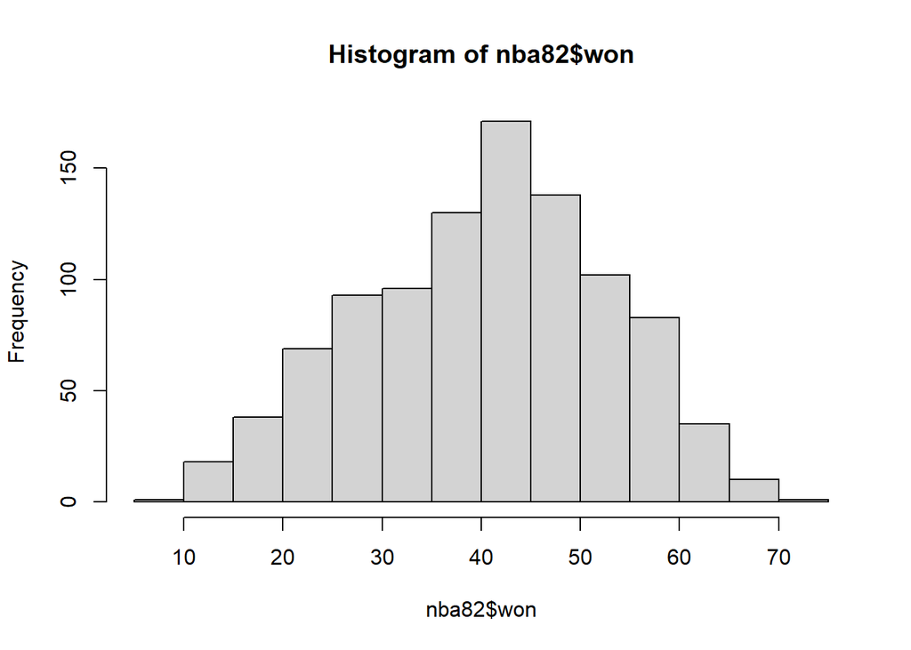

```r
# sUPPONIAMO la variabile risposta essere "won", per le stagione in cui le gare sono state 82

nba82 = ds[ds$lgID=="NBA" & ds$games==82,]

# histogram
hist(nba82$won)
```

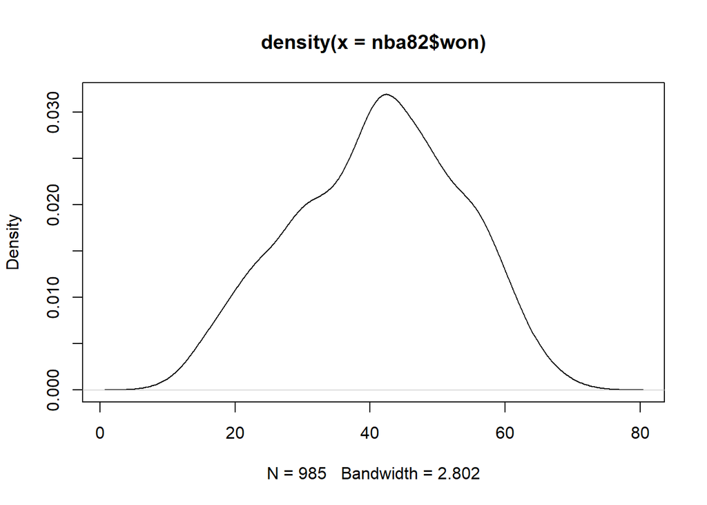

```r
#plot density
plot(density(nba82$won))
```

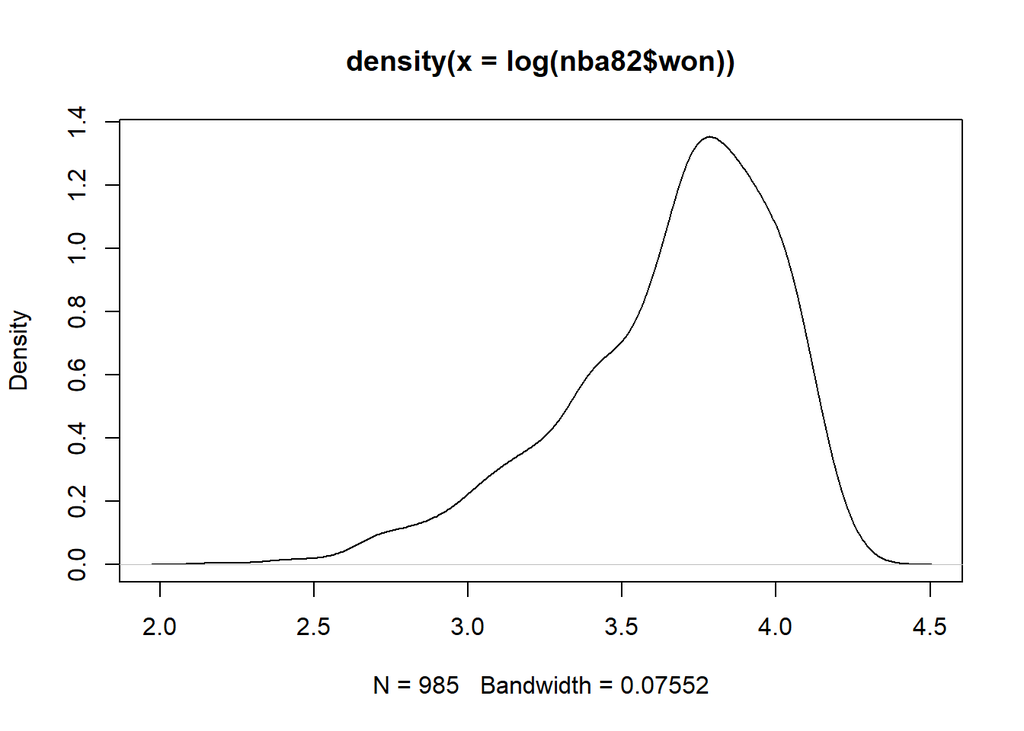

```r
# buon adattamento normale
# altrimenti log trasfomation

plot(density(log(nba82$won)))
```

```r
# meglio di no
```

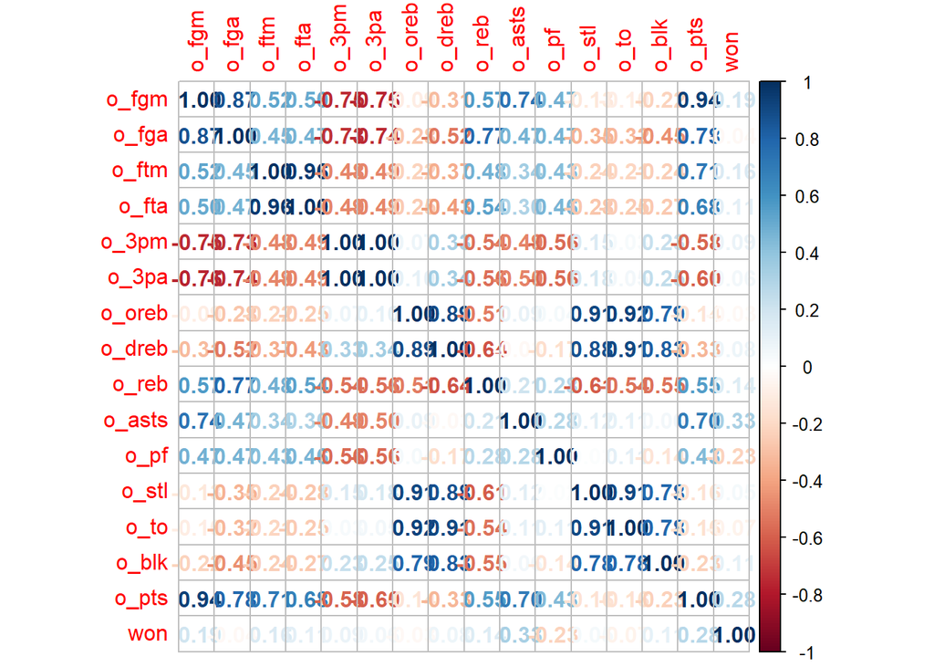

```r
library("corrplot")
M <- cor(as.matrix(nba82[,c(11:25,54)]))
         # correlation matrix
corrplot(M, method = 'number')
```

# Analisi distribuzione variabili esplicative

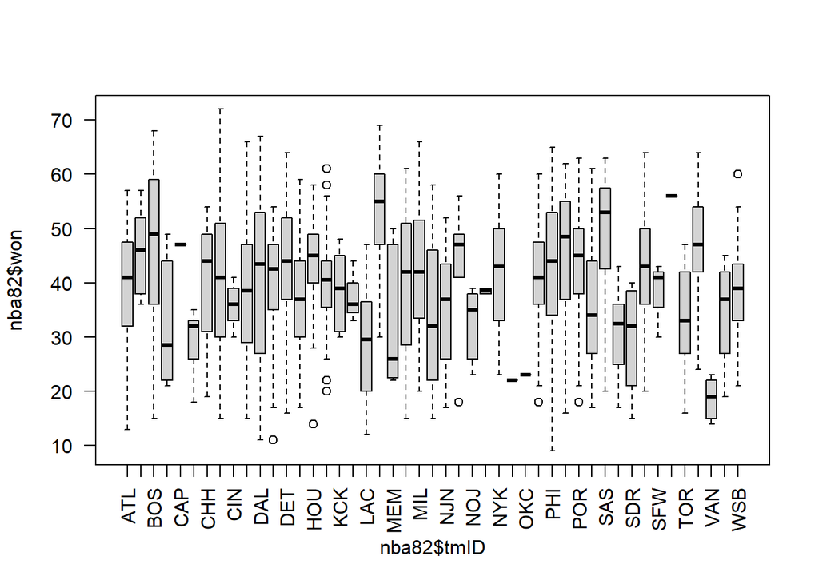

```r
# variabili fattori
boxplot(nba82$won ~ nba82$tmID, las=2)
```

# Modello di regressione lineare

```r
# stimo il modello
(res1 = lm(won ~ o_fgm, data = nba82))
```

```
##
## Call:
## lm(formula = won ~ o_fgm, data = nba82)
##
## Coefficients:
## (Intercept)        o_fgm
##   15.846993     0.007651
```

```r
(res2 = lm(won ~ o_fgm + o_fga, data = nba82))
```

```
##
## Call:
## lm(formula = won ~ o_fgm + o_fga, data = nba82)
##
## Coefficients:
## (Intercept)        o_fgm        o_fga
##    55.46086      0.03565     -0.01860
```

```r
# creo nuova variabile (percentuale di tiro dal campo)
nba82$o_fgpc = nba82$o_fgm / nba82$o_fga * 100
(res3 = lm(won ~ o_fgpc, data = nba82))
```

```
##
## Call:
## lm(formula = won ~ o_fgpc, data = nba82)
##
## Coefficients:
## (Intercept)       o_fgpc
##     -75.115        2.501
```

```r
# dipende anche da percentuale tiro dal campo squadra avversaria
nba82$d_fgpc = nba82$d_fgm / nba82$d_fga * 100
(res4 = lm(won ~ o_fgpc + d_fgpc, data = nba82))
```

```
##
## Call:
## lm(formula = won ~ o_fgpc + d_fgpc, data = nba82)
##
## Coefficients:
## (Intercept)       o_fgpc       d_fgpc
##      46.712        4.082       -4.206
```

```r
# dipende anche dai rimbalzi totali di dquadra e degli avversari
(res5 = lm(won ~ o_fgpc + d_fgpc + o_reb + d_reb, data = nba82))
```

```
##
## Call:
## lm(formula = won ~ o_fgpc + d_fgpc + o_reb + d_reb, data = nba82)
##
## Coefficients:
## (Intercept)       o_fgpc       d_fgpc        o_reb        d_reb
##   36.119445     3.715539    -3.741371     0.010803    -0.009118
```

```r
# variabili fattori (dummy)
table(nba82$tmID)
```

```
##
## ATL BAL BOS BUF CAP CHA CHH CHI CIN CLE DAL DEN DET GSW HOU IND KCK KCO LAC LAL
##  40   6  41   8   1   5  13  41   5  38  28  32  41  37  37  32  10   3  24  41
## MEM MIA MIL MIN NJN NOH NOJ NOK NYK NYN OKC ORL PHI PHO POR SAC SAS SDC SDR SEA
##   8  20  40  19  31   5   5   2  41   1   1  19  41  40  38  23  32   6   4  40
## SFW STL TOR UTA VAN WAS WSB
##   4   1  13  29   5  11  23
```

```r
#media vittorie in più rispetto ad Atlanta
(res6 = lm(won ~ o_fgpc + d_fgpc + tmID, data = nba82))
```

```
##
## Call:
## lm(formula = won ~ o_fgpc + d_fgpc + tmID, data = nba82)
##
## Coefficients:
## (Intercept)       o_fgpc       d_fgpc      tmIDBAL      tmIDBOS      tmIDBUF
##     52.9352       4.0193      -4.2446      -1.2552       1.2963      -8.3530
##     tmIDCAP      tmIDCHA      tmIDCHH      tmIDCHI      tmIDCIN      tmIDCLE
##      7.9195      -4.8144      -0.4175       0.8304      -7.0930      -1.6452
##     tmIDDAL      tmIDDEN      tmIDDET      tmIDGSW      tmIDHOU      tmIDIND
##      2.6910       1.8011       1.0447      -0.8165      -1.0844      -3.6409
##     tmIDKCK      tmIDKCO      tmIDLAC      tmIDLAL      tmIDMEM      tmIDMIA
##     -2.9061       0.2285      -8.1613       0.7013      -6.8261      -4.8078
##     tmIDMIL      tmIDMIN      tmIDNJN      tmIDNOH      tmIDNOJ      tmIDNOK
##     -3.4346      -7.3929      -1.0252       3.3579      -5.4860       1.8192
##     tmIDNYK      tmIDNYN      tmIDOKC      tmIDORL      tmIDPHI      tmIDPHO
##     -3.2089      -6.4934      -7.8009      -2.4613      -0.3300      -1.2861
##     tmIDPOR      tmIDSAC      tmIDSAS      tmIDSDC      tmIDSDR      tmIDSEA
##     -0.4813      -3.5023      -1.2378       0.1246       8.5104       0.7785
##     tmIDSFW      tmIDTOR      tmIDUTA      tmIDVAN      tmIDWAS      tmIDWSB
##    -10.3433      -2.0470      -5.4509     -11.7602      -0.8208      -3.0408
```

```r
# Dean's 4 factors
nba82$o_df1 = (nba82$o_fgm + 0.5*nba82$o_3pm) / nba82$o_fga
nba82$d_df1 = (nba82$d_fgm + 0.5*nba82$d_3pm) / nba82$d_fga
nba82$o_df2 = nba82$o_to / (nba82$o_to + nba82$o_fga + 0.44*nba82$o_fta)
nba82$d_df2 = nba82$d_to / (nba82$d_to + nba82$d_fga + 0.44*nba82$d_fta)
nba82$o_df3 = nba82$o_oreb / (nba82$o_oreb + nba82$d_dreb)
nba82$d_df3 = nba82$d_oreb / (nba82$d_oreb + nba82$o_dreb)
nba82$o_df4 = nba82$o_ftm / nba82$o_fga
nba82$d_df4 = nba82$d_ftm / nba82$d_fga

(res7 = lm(won ~ o_df1 + d_df1 + o_df2 + d_df2 + o_df3 + d_df3 + o_df4 + d_df4, data= nba82))
```

```
##
## Call:
## lm(formula = won ~ o_df1 + d_df1 + o_df2 + d_df2 + o_df3 + d_df3 +
##     o_df4 + d_df4, data = nba82)
##
## Coefficients:
## (Intercept)        o_df1        d_df1        o_df2        d_df2        o_df3
##       9.636      371.165     -172.082     -397.020      299.596       77.863
##       d_df3        o_df4        d_df4
##    -208.414       86.876     -124.371
```

```r
summary(res7)
```

```
##
## Call:
## lm(formula = won ~ o_df1 + d_df1 + o_df2 + d_df2 + o_df3 + d_df3 +
##     o_df4 + d_df4, data = nba82)
##
## Residuals:
##      Min       1Q   Median       3Q      Max
## -17.8233  -3.3726   0.0308   3.6245  14.8253
##
## Coefficients:
##             Estimate Std. Error t value Pr(>|t|)
## (Intercept)    9.636      6.754   1.427    0.154
## o_df1        371.165      9.558  38.834   <2e-16 ***
## d_df1       -172.082      6.522 -26.383   <2e-16 ***
## o_df2       -397.020     15.840 -25.064   <2e-16 ***
## d_df2        299.596     14.143  21.183   <2e-16 ***
## o_df3         77.863      6.692  11.635   <2e-16 ***
## d_df3       -208.414      7.385 -28.220   <2e-16 ***
## o_df4         86.876      7.184  12.093   <2e-16 ***
## d_df4       -124.371      6.874 -18.094   <2e-16 ***
## ---
## Signif. codes:  0 '***' 0.001 '**' 0.01 '*' 0.05 '.' 0.1 ' ' 1
##
## Residual standard error: 5.205 on 885 degrees of freedom
##   (91 osservazioni eliminate a causa di valori mancanti)
## Multiple R-squared:  0.8218, Adjusted R-squared:  0.8202
## F-statistic: 510.1 on 8 and 885 DF,  p-value: < 2.2e-16
```